# Analysis of Shihong’s pest exclusion experiment

Robert Bagchi

08 March, 2017

### 1. Preliminaries

```r
library(ggplot2)
library(cowplot)
library(lme4)
library(pbkrtest)
library(tidyr)
library(dplyr)
library(optimx)
library(broom)
```

### 2. Organise data

```r
rm(list=ls())

## Read in data
pestdat <- read.csv("../data/Pestwoodyseedlings_20170116.csv")
## reorder the factors in a sensible order
pestdat$pesticide <- factor(pestdat$pesticide, levels=c('C', 'W', 'F', 'I'))
pestdat$exclosure <- factor(pestdat$exclosure)
pestdat$growth.form <- factor(pestdat$growth.form, levels=c('tree', 'shrub'))
pestdat$propagation <- factor(pestdat$propagation, levels=c('sexual', 'asexual'))

## there is occasionally trailing white space on some of the species names.
## Removing this to prevent problems later.
pestdat$species <- factor(trimws(as.character(pestdat$species)))

## functions to add up number of seedlings in and number of deaths
totcalc <-  function(x) sum(!is.na(x) & x> 0)
deathcalc <- function(x) sum(!is.na(x) & x==0)


pestdat.ag <- summarise(group_by(pestdat, site, code, quadrat, species,
                                  pesticide, exclosure, growth.form, propagation),
          total_16s=totcalc(height_15f),  total_16f=totcalc(height_16s),
          deaths_16s=deathcalc(height_16s), deaths_16f=deathcalc(height_16f))

pestdat.ag <-  gather(pestdat.ag, "meas", "N", total_16s:deaths_16f) %>%
  separate(meas, into=c("meas", "census"), sep="_") %>%
  spread(meas, N)
## calculate no. survivors as total - deaths
pestdat.ag$survs <- pestdat.ag$total - pestdat.ag$deaths

pestdat.ag <- subset(pestdat.ag, total > 0)

## get idea of representation of treatments
group_by(pestdat.ag, growth.form, propagation) %>% tally
```

```
## Source: local data frame [4 x 3]
## Groups: growth.form [?]
##
##   growth.form propagation     n
##        <fctr>      <fctr> <int>
## 1        tree      sexual   792
## 2        tree     asexual     7
## 3       shrub      sexual   203
## 4       shrub     asexual   780
```

```r
pestdat.ag$quad.unique <- as.factor(paste(pestdat.ag$site,
                                          pestdat.ag$exclosure,
                                          pestdat.ag$quadrat, sep='_'))
pestdat.ag$plot <- as.factor(paste(pestdat.ag$site, pestdat.ag$exclosure,
                                   sep='_'))
```

### 3. Initial plots

Now some initial plots

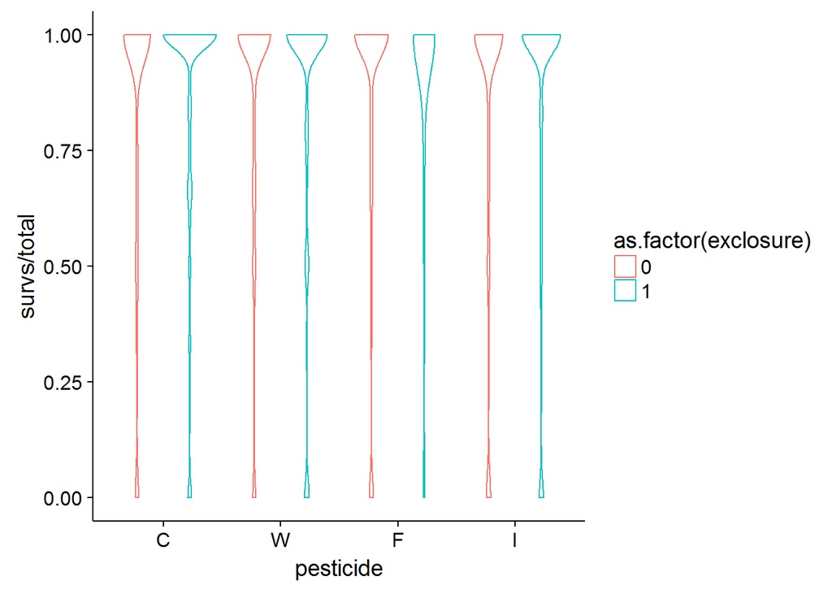

```r
ggplot(data=pestdat.ag,
       aes(x=pesticide, y=survs/total, colour=as.factor(exclosure))) + geom_violin()
```

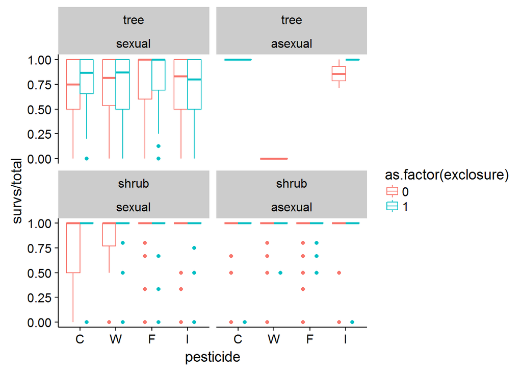

```r
ggplot(data=pestdat.ag,
       aes(x=pesticide, y=survs/total, colour=as.factor(exclosure))) +
  geom_boxplot() +
  facet_wrap(~growth.form + propagation)
```

```r
summary(pestdat.ag)
```

|  | site | code | quadrat | species | pesticide | exclosure | growth.form | propagation | census | deaths | total | survs | quad.unique | plot |
| --- | --- | --- | --- | --- | --- | --- | --- | --- | --- | --- | --- | --- | --- | --- |
|  | Min. :1.00 | Min. :101 | Min. :101 | Fraxinus mandschurica :328 | C:428 | 0:939 | tree :799 | sexual :995 | Length:1782 | Min. : 0.00 | Min. : 1.00 | Min. : 0.0 | 1_1_407: 18 | 1_0:358 |
|  | 1st Qu.:1.00 | 1st Qu.:102 | 1st Qu.:202 | Tilia amurensis :244 | W:445 | 1:843 | shrub:983 | asexual:787 | Class :character | 1st Qu.: 0.00 | 1st Qu.: 1.00 | 1st Qu.: 1.0 | 1_1_503: 16 | 1_1:356 |
|  | Median :2.00 | Median :103 | Median :304 | Philadelphus schrenkii:161 | F:466 | NA | NA | NA | Mode :character | Median : 0.00 | Median : 1.00 | Median : 1.0 | 1_0_510: 15 | 2_0:352 |
|  | Mean :1.82 | Mean :103 | Mean :305 | Euonymus macropterus :142 | I:443 | NA | NA | NA | NA | Mean : 0.55 | Mean : 2.75 | Mean : 2.2 | 1_1_308: 15 | 2_1:319 |
|  | 3rd Qu.:2.00 | 3rd Qu.:104 | 3rd Qu.:409 | Acer barbinerve :137 | NA | NA | NA | NA | NA | 3rd Qu.: 1.00 | 3rd Qu.: 3.00 | 3rd Qu.: 2.0 | 2_0_510: 15 | 3_0:229 |
|  | Max. :3.00 | Max. :107 | Max. :510 | Euonymus alatus : 78 | NA | NA | NA | NA | NA | Max. :14.00 | Max. :23.00 | Max. :20.0 | 2_1_405: 15 | 3_1:168 |
|  | NA | NA | NA | (Other) :692 | NA | NA | NA | NA | NA | NA | NA | NA | (Other):1688 | NA |

```
## Warning: Removed 1 rows containing missing values (geom_errorbar).
```

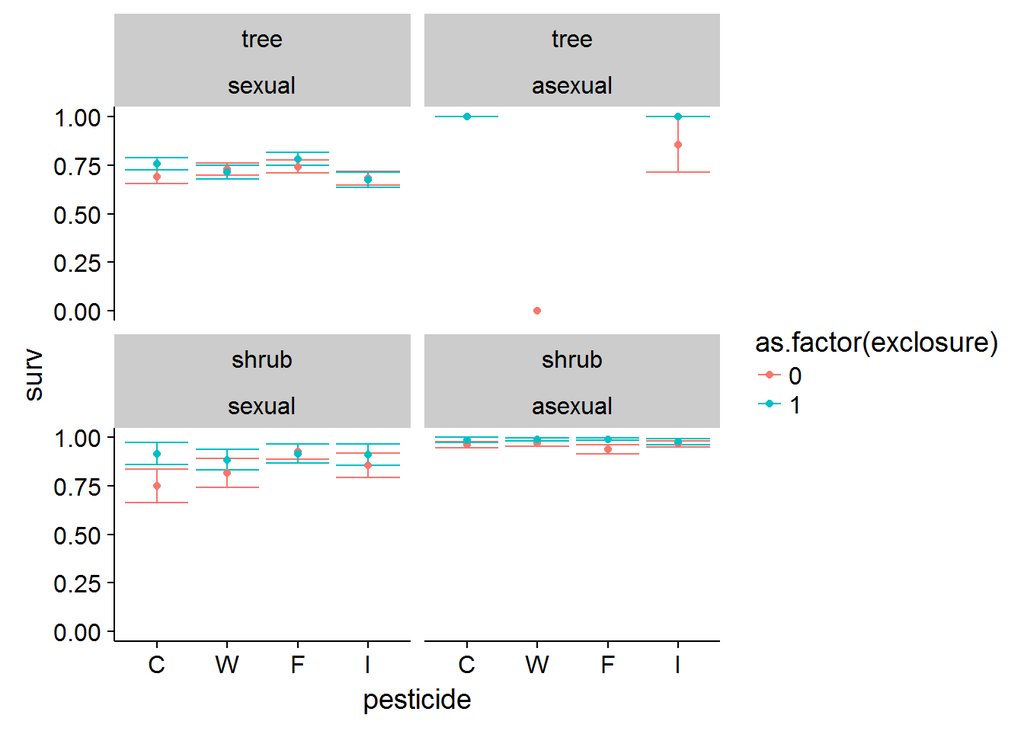

```r
group_by(pestdat.ag, pesticide, exclosure, propagation, growth.form) %>%
  summarise(surv = mean(survs/total),
            se.survs=sd(survs/total)/sqrt(length(survs/total))) %>%
ggplot(aes(x=pesticide, y=surv, ymin=surv-se.survs, ymax=surv+se.survs,
           colour=as.factor(exclosure))) + geom_errorbar() + geom_point() +
    facet_wrap(~growth.form + propagation)
```

Overall, difficult to see what might be going on here - no dramatic trends.

## 4. Initial models

First let us model survival as a function of treatments (pesticide and exclosure) and looking at growth forms separately. We had some issues with convergence using the default optimisers, so switched to those in the optimx package that worked better. Differences between fits were small, despite the convergence warnings. The plot level random effects had close to 0 variance and were therefore dropped from further analyses.

```r
pestdat.ag$site <- factor(pestdat.ag$site)
contrasts(pestdat.ag$site) <- "contr.sum"

summary(pestdat.ag)
```

|  | site | code | quadrat | species | pesticide | exclosure | growth.form | propagation | census | deaths | total | survs | quad.unique | plot |
| --- | --- | --- | --- | --- | --- | --- | --- | --- | --- | --- | --- | --- | --- | --- |
|  | 1:714 | Min. :101 | Min. :101 | Fraxinus mandschurica :328 | C:428 | 0:939 | tree :799 | sexual :995 | Length:1782 | Min. : 0.00 | Min. : 1.00 | Min. : 0.0 | 1_1_407: 18 | 1_0:358 |
|  | 2:671 | 1st Qu.:102 | 1st Qu.:202 | Tilia amurensis :244 | W:445 | 1:843 | shrub:983 | asexual:787 | Class :character | 1st Qu.: 0.00 | 1st Qu.: 1.00 | 1st Qu.: 1.0 | 1_1_503: 16 | 1_1:356 |
|  | 3:397 | Median :103 | Median :304 | Philadelphus schrenkii:161 | F:466 | NA | NA | NA | Mode :character | Median : 0.00 | Median : 1.00 | Median : 1.0 | 1_0_510: 15 | 2_0:352 |
|  | NA | Mean :103 | Mean :305 | Euonymus macropterus :142 | I:443 | NA | NA | NA | NA | Mean : 0.55 | Mean : 2.75 | Mean : 2.2 | 1_1_308: 15 | 2_1:319 |
|  | NA | 3rd Qu.:104 | 3rd Qu.:409 | Acer barbinerve :137 | NA | NA | NA | NA | NA | 3rd Qu.: 1.00 | 3rd Qu.: 3.00 | 3rd Qu.: 2.0 | 2_0_510: 15 | 3_0:229 |
|  | NA | Max. :107 | Max. :510 | Euonymus alatus : 78 | NA | NA | NA | NA | NA | Max. :14.00 | Max. :23.00 | Max. :20.0 | 2_1_405: 15 | 3_1:168 |
|  | NA | NA | NA | (Other) :692 | NA | NA | NA | NA | NA | NA | NA | NA | (Other):1688 | NA |

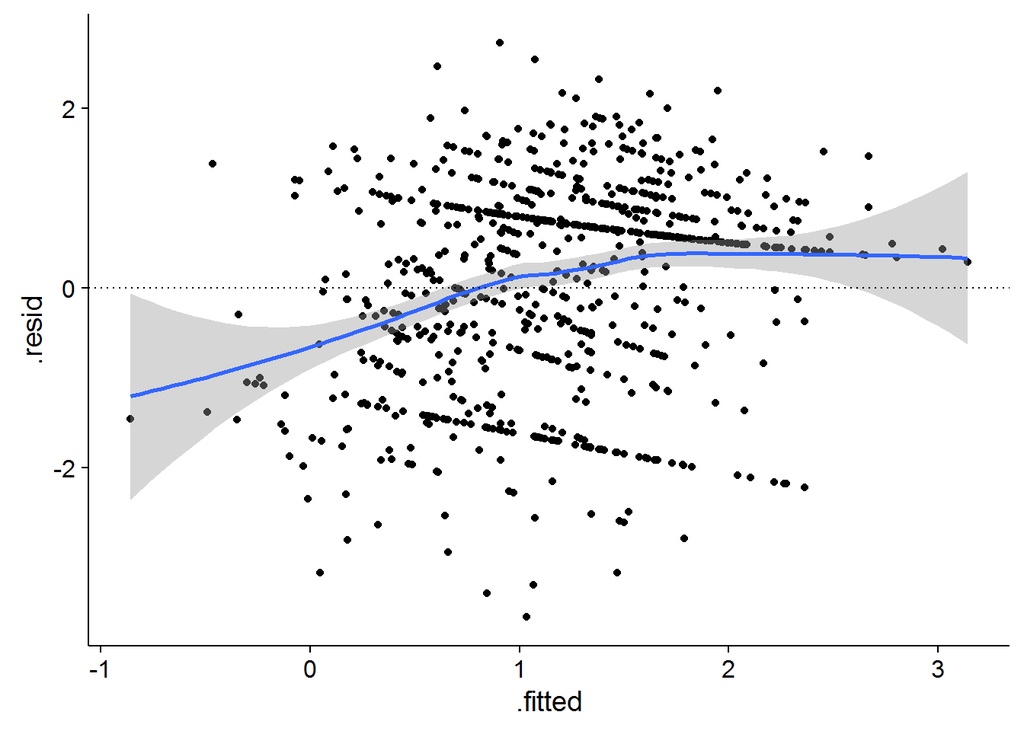

```r
mod.tree <- glmer(cbind(survs, deaths) ~ site + pesticide*exclosure +
                (1|quad.unique) + (1|species),
              data=subset(pestdat.ag, growth.form=='tree'), family=binomial,
              control=glmerControl(optimizer="optimx",
                                   optCtrl=list(method=c('bobyqa', 'Nelder-Mead'))))

mod.tree.diags <- augment(mod.tree)
qplot(data=mod.tree.diags, x=.fitted, y=.resid, geom=c('point', 'smooth')) +
  geom_hline(yintercept=0, linetype='dotted')
```

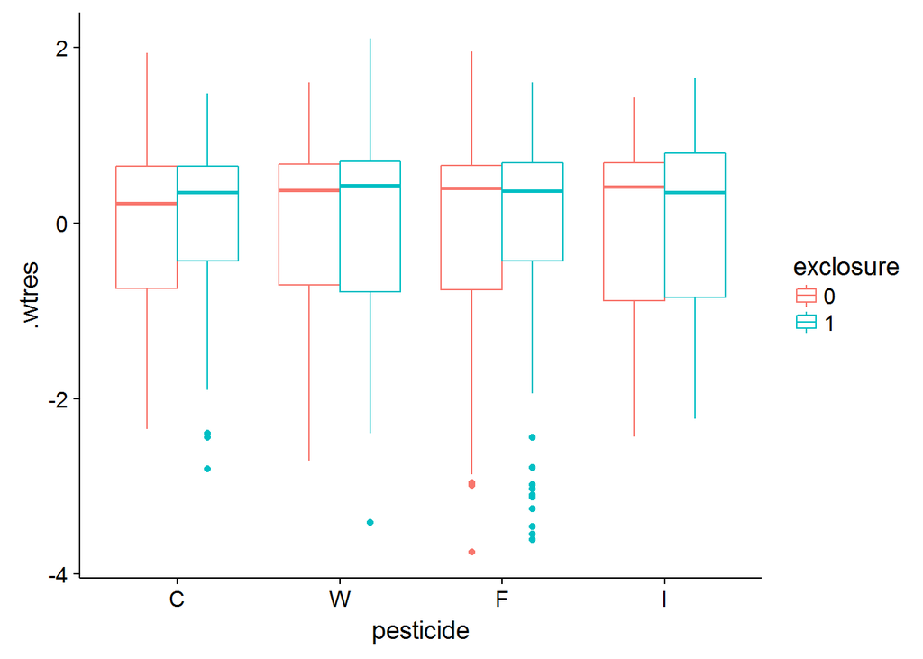

```r
qplot(data = mod.tree.diags, x= pesticide, y=.wtres, geom="boxplot", colour=exclosure)
```

```r
names(mod.tree.diags)
```

```
##  [1] "cbind.survs..deaths." "site"                 "pesticide"
##  [4] "exclosure"            "quad.unique"          "species"
##  [7] ".fitted"              ".resid"               ".fixed"
## [10] ".mu"                  ".offset"              ".sqrtXwt"
## [13] ".sqrtrwt"             ".weights"             ".wtres"
## [16] ".eta"
```

```r
library(gridExtra)
```

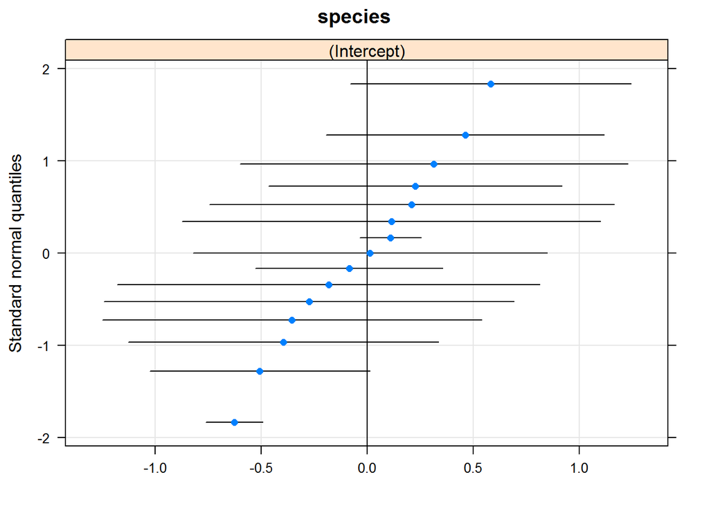

```r
library(lattice)
qqmath(ranef(mod.tree,  condVar=TRUE, whichel="species"))
```

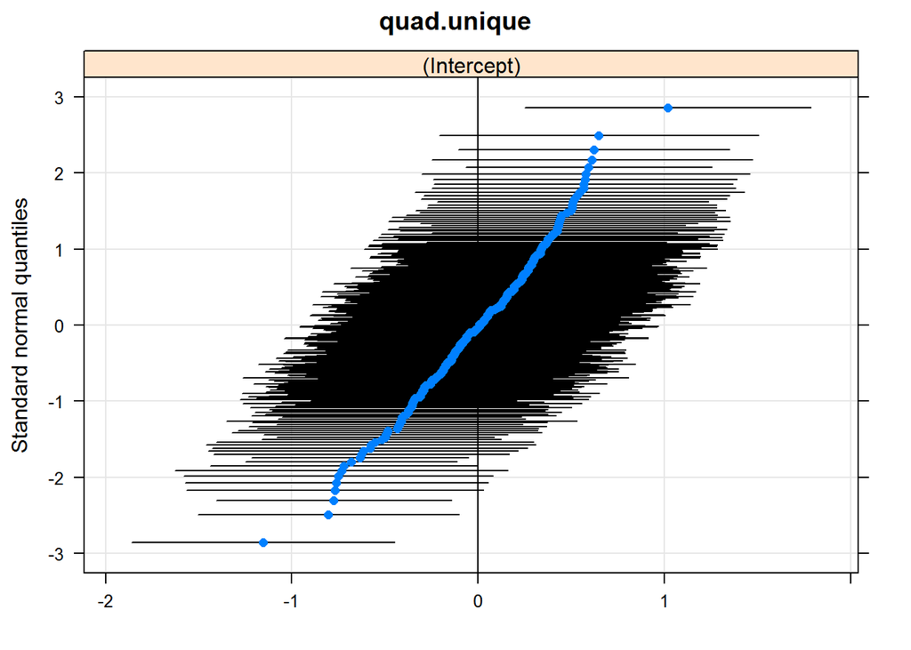

```r
qqmath(ranef(mod.tree,  condVar=TRUE, whichel="quad.unique"))
```

```r
summary(mod.tree)
```

```
## Generalized linear mixed model fit by maximum likelihood (Laplace
##   Approximation) [glmerMod]
##  Family: binomial  ( logit )
## Formula:
## cbind(survs, deaths) ~ site + pesticide * exclosure + (1 | quad.unique) +
##     (1 | species)
##    Data: subset(pestdat.ag, growth.form == "tree")
## Control:
## glmerControl(optimizer = "optimx", optCtrl = list(method = c("bobyqa",
##     "Nelder-Mead")))
##
##      AIC      BIC   logLik deviance df.resid
##     1971     2027     -974     1947      787
##
## Scaled residuals:
##    Min     1Q Median     3Q    Max
## -3.750 -0.737  0.383  0.687  2.107
##
## Random effects:
##  Groups      Name        Variance Std.Dev.
##  quad.unique (Intercept) 0.293    0.541
##  species     (Intercept) 0.274    0.523
## Number of obs: 799, groups:  quad.unique, 236; species, 15
##
## Fixed effects:
##                       Estimate Std. Error z value Pr(>|z|)
## (Intercept)             1.0731     0.2542    4.22  2.4e-05 ***
## site1                   0.0213     0.0828    0.26   0.7975
## site2                  -0.2331     0.0769   -3.03   0.0024 **
## pesticideW              0.0445     0.2214    0.20   0.8406
## pesticideF              0.4935     0.2228    2.22   0.0267 *
## pesticideI              0.0829     0.2269    0.37   0.7147
## exclosure1              0.2541     0.2300    1.11   0.2691
## pesticideW:exclosure1  -0.1002     0.3175   -0.32   0.7523
## pesticideF:exclosure1  -0.0469     0.3176   -0.15   0.8825
## pesticideI:exclosure1  -0.2350     0.3213   -0.73   0.4645
## ---
## Signif. codes:  0 '***' 0.001 '**' 0.01 '*' 0.05 '.' 0.1 ' ' 1
##
## Correlation of Fixed Effects:
##             (Intr) site1  site2  pstcdW pstcdF pstcdI excls1 pstW:1 pstF:1
## site1        0.004
## site2       -0.039 -0.454
## pesticideW  -0.458  0.026 -0.016
## pesticideF  -0.453  0.001 -0.022  0.532
## pesticideI  -0.461  0.007 -0.033  0.519  0.517
## exclosure1  -0.436 -0.012 -0.023  0.512  0.510  0.501
## pstcdW:xcl1  0.315 -0.025  0.031 -0.697 -0.371 -0.362 -0.722
## pstcdF:xcl1  0.317  0.017  0.008 -0.370 -0.698 -0.361 -0.723  0.522
## pstcdI:xcl1  0.326 -0.006  0.025 -0.367 -0.366 -0.706 -0.715  0.517  0.517
```

```r
mod.tree.dd <- glmer(cbind(survs, deaths) ~ site + total*pesticide*exclosure +
                       (1|quad.unique) + (1|species),
                     data=subset(pestdat.ag, growth.form=='tree'), family=binomial,
                     control=glmerControl(optimizer="optimx",
                                          optCtrl=list(method=c('bobyqa', 'Nelder-Mead'))))

summary(mod.tree.dd)
```

```
## Generalized linear mixed model fit by maximum likelihood (Laplace
##   Approximation) [glmerMod]
##  Family: binomial  ( logit )
## Formula: cbind(survs, deaths) ~ site + total * pesticide * exclosure +
##     (1 | quad.unique) + (1 | species)
##    Data: subset(pestdat.ag, growth.form == "tree")
## Control:
## glmerControl(optimizer = "optimx", optCtrl = list(method = c("bobyqa",
##     "Nelder-Mead")))
##
##      AIC      BIC   logLik deviance df.resid
##     1961     2055     -961     1921      779
##
## Scaled residuals:
##    Min     1Q Median     3Q    Max
## -3.539 -0.647  0.380  0.713  2.101
##
## Random effects:
##  Groups      Name        Variance Std.Dev.
##  quad.unique (Intercept) 0.303    0.551
##  species     (Intercept) 0.368    0.607
## Number of obs: 799, groups:  quad.unique, 236; species, 15
##
## Fixed effects:
##                             Estimate Std. Error z value Pr(>|z|)
## (Intercept)                   0.4826     0.3390    1.42  0.15461
## site1                         0.0398     0.0838    0.47  0.63532
## site2                        -0.3102     0.0799   -3.88  0.00010 ***
## total                         0.1308     0.0374    3.50  0.00047 ***
## pesticideW                    0.7976     0.3630    2.20  0.02802 *
## pesticideF                    0.8492     0.3636    2.34  0.01951 *
## pesticideI                    0.3763     0.3632    1.04  0.30011
## exclosure1                    0.9137     0.3723    2.45  0.01413 *
## total:pesticideW             -0.1261     0.0450   -2.81  0.00503 **
## total:pesticideF             -0.0763     0.0446   -1.71  0.08707 .
## total:pesticideI             -0.0478     0.0492   -0.97  0.33123
## total:exclosure1             -0.1119     0.0464   -2.41  0.01603 *
## pesticideW:exclosure1        -0.8228     0.5085   -1.62  0.10566
## pesticideF:exclosure1        -0.5838     0.5322   -1.10  0.27269
## pesticideI:exclosure1        -0.7176     0.5148   -1.39  0.16333
## total:pesticideW:exclosure1   0.1199     0.0580    2.07  0.03862 *
## total:pesticideF:exclosure1   0.0961     0.0603    1.59  0.11097
## total:pesticideI:exclosure1   0.0682     0.0617    1.11  0.26894
## ---
## Signif. codes:  0 '***' 0.001 '**' 0.01 '*' 0.05 '.' 0.1 ' ' 1
```

```
##
## Correlation matrix not shown by default, as p = 18 > 12.
## Use print(x, correlation=TRUE)  or
##   vcov(x)     if you need it
```

Now we can model the shrub data. Including the Nelder-Mead optimizer led to warnings - however, just using bobyqa solved them. Additionally, I removed the 3 way interaction between propagation, pesticide and exclosure.

```r
mod.shrub <- glmer(cbind(survs, deaths) ~ site + (propagation+pesticide+exclosure)^2 +
                (1|quad.unique) + (1|species),
              data=subset(pestdat.ag, growth.form=='shrub'), family=binomial,
              control=glmerControl(optimizer="optimx", optCtrl=list(method='bobyqa')))
```

### 5. Density dependence

Ultimately we are interested in not only whether or not pesticides improve survival, but also whether survival is density dependent and if pesticides remove that density dependence. The next analysis examines the evidence for density dependence.

First let us look at some plots of survival against density.

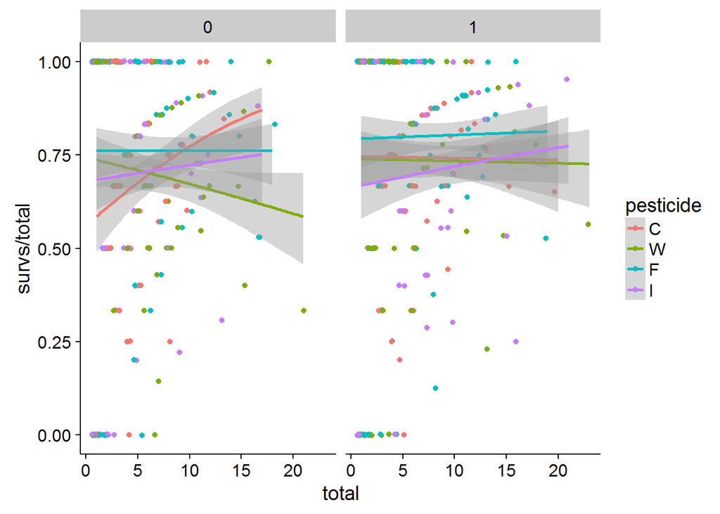

```r
## For all tree species together
ggplot(data=subset(pestdat.ag, growth.form=='tree'),
       aes(x=total, y=survs/total, colour=pesticide)) +
  geom_jitter()+
  geom_smooth(aes(weight = total), method='glm', method.args=list(family="binomial")) +
  facet_wrap(~exclosure)
```

```r
## And now pulling the species apart.
## First need to filter down to species that can be analysed - need enough
## reps (lets say 5) and variation in abundance (at least 2x
sp.counts <- summarise(group_by(pestdat.ag, species),
          n.quadrat=length(total), max.dens=max(total), min.dens=min(total))

sp.counts$range <- sp.counts$max.dens - sp.counts$min.dens
sp.sel <- sp.counts$species[sp.counts$n.quadrat > 10 & sp.counts$range >=3]
sp.counts[sp.counts$species %in% sp.sel,]
```

| species | n.quadrat | max.dens | min.dens | range |
| --- | --- | --- | --- | --- |
| Acer barbinerve | 137 | 14 | 1 | 13 |
| Acer tegmentosum | 60 | 4 | 1 | 3 |
| Celastrus orbiculatus | 43 | 5 | 1 | 4 |
| Euonymus alatus | 78 | 4 | 1 | 3 |
| Euonymus macropterus | 142 | 5 | 1 | 4 |
| Fraxinus mandschurica | 328 | 23 | 1 | 22 |
| Philadelphus schrenkii | 161 | 5 | 1 | 4 |
| Pinus koraiensis | 24 | 8 | 1 | 7 |
| Ribes maximowiczianum | 61 | 5 | 1 | 4 |
| Spiraea chamaedryfolia | 74 | 5 | 1 | 4 |
| Syringa reticulata | 51 | 5 | 1 | 4 |
| Tilia amurensis | 244 | 21 | 1 | 20 |

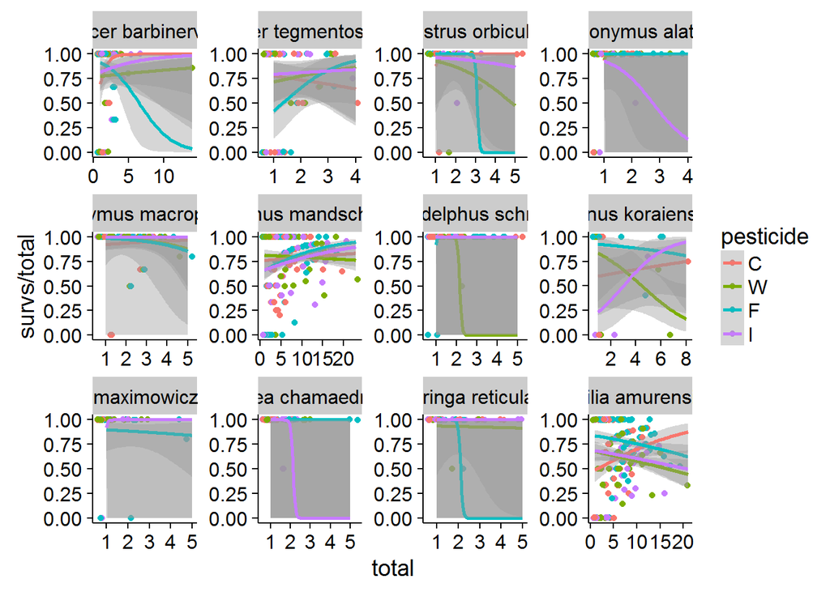

```r
ggplot(data=subset(pestdat.ag, species %in% sp.sel),
       aes(x=total, y=survs/total, colour=pesticide)) +
  geom_jitter()+
  geom_smooth(aes(weight = total), method='glm',
              method.args=list(family="binomial"), fullrange=T) +
  facet_wrap(~ species,  scales='free')
```

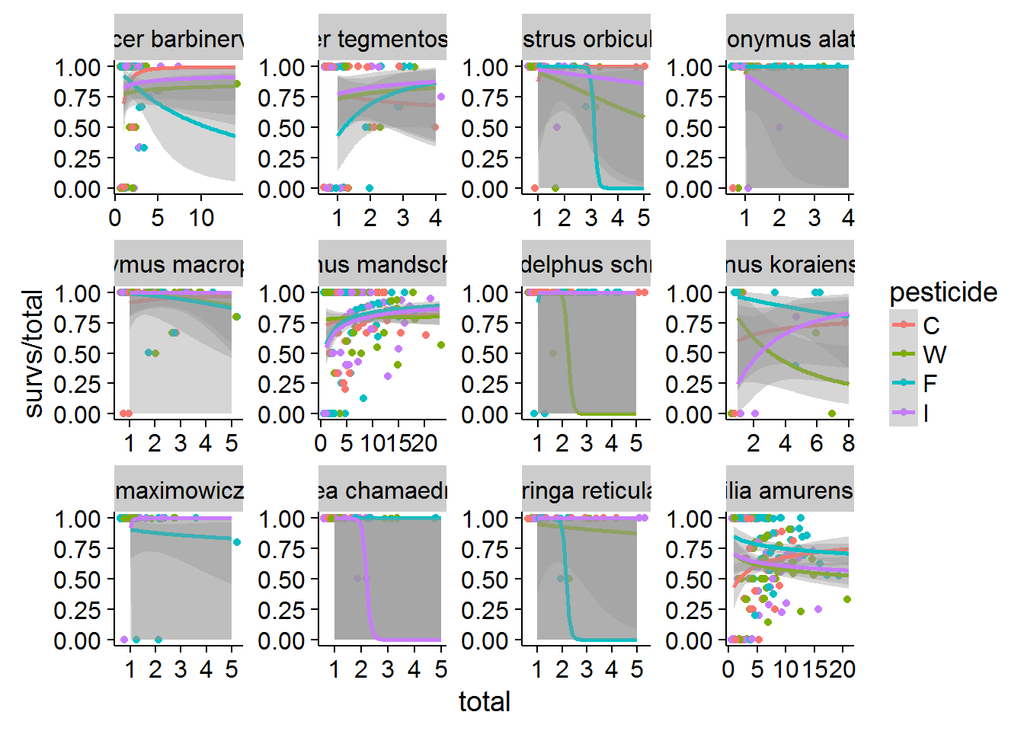

```r
## try using log density
ggplot(data=subset(pestdat.ag, species %in% sp.sel),
       aes(x=total, y=survs/total, colour=pesticide)) +
  geom_jitter()+
  geom_smooth(aes(weight = total), method='glm', formula=y~log(x),
              method.args=list(family="binomial"), fullrange=T) +
  facet_wrap(~ species,  scales='free')
```

Pretty hard to make too much out from these plots. It does appear that only about 4 species(*Acer barbinerve, A. tegmentosum, Fraxinus mandschurica, and Tilia amurensis*) have enough data to say much at all. *Pinus koraiensis* looked a possibility, but models don’t seem to fit very well. The confidence intervals on the others are huge and go from 0 to 1. Looking at htose species it looks like if anything, survival increases with density.

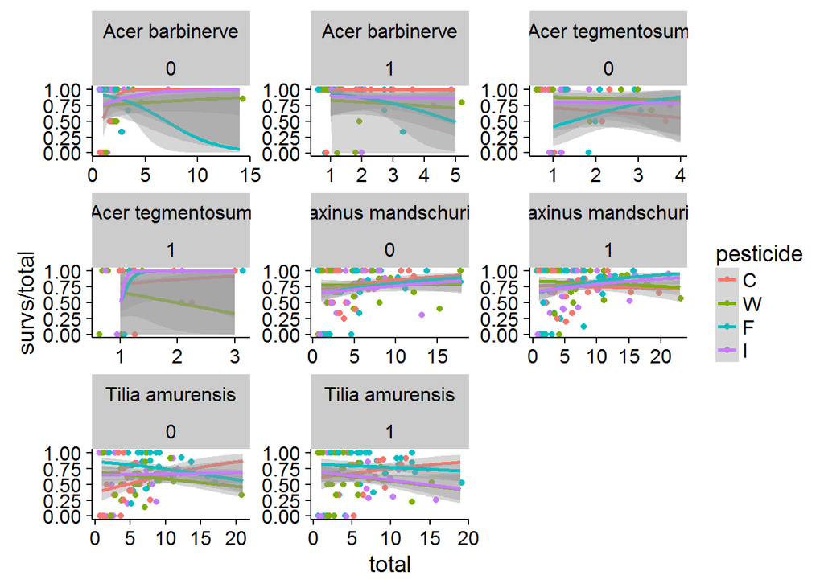

```r
## quick plot of only the species for which there appear to be enough data
sp.sel2 <- c('Acer barbinerve', 'Acer tegmentosum',
             'Fraxinus mandschurica', 'Tilia amurensis')

ggplot(data=subset(pestdat.ag, species %in% sp.sel2),
       aes(x=total, y=survs/total, colour=pesticide)) +
  geom_jitter()+
  geom_smooth(aes(weight = total), method='glm',
              method.args=list(family="binomial"), fullrange=T) +
  facet_wrap(~ species + exclosure,  scales='free')
```

```r
nddmods <- sapply(sp.sel2, function(sp){
  print(sp)
    spdat <- filter(pestdat.ag, species == sp)
  ## to increase ability to fit models, standardise total
  spdat$dens <- (spdat$total - mean(spdat$total))/(2*sd(spdat$total))
  spdat <- droplevels(spdat)
  mod <- glmer(cbind(survs, deaths) ~ site + dens*(pesticide+exclosure) + (1|quad.unique),
               data=spdat, family=binomial,
               control=glmerControl(optimizer="optimx",
                                    optCtrl=list(method=c('bobyqa', 'Nelder-Mead')))
  )
}, simplify=FALSE)
```

```
## [1] "Acer barbinerve"
## [1] "Acer tegmentosum"
## [1] "Fraxinus mandschurica"
## [1] "Tilia amurensis"
```

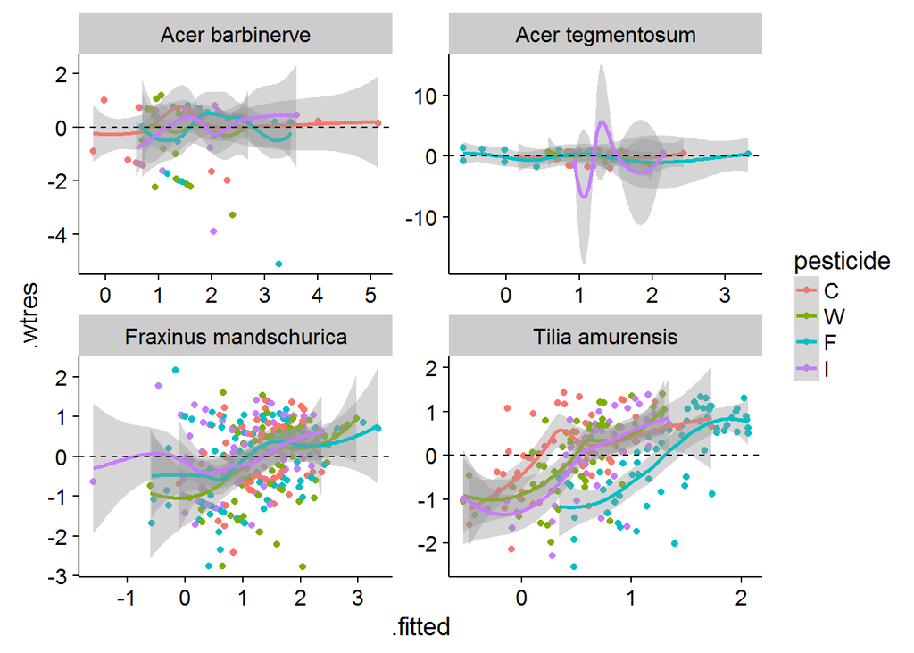

```r
## diagnostic plots
indmods.resids <- lapply(nddmods, augment)

indmods.resids <- do.call('rbind', mapply(function(spnm, dat) {
  dat$species <- spnm
  return(dat)
  }, spnm=as.list(names(indmods.resids)), dat=indmods.resids,
  SIMPLIFY=FALSE))

ggplot(data=indmods.resids, aes(x=.fitted, y=.wtres, colour=pesticide)) +
  geom_jitter() + geom_smooth() + facet_wrap(~species, scales='free') +
  geom_hline(yintercept=0, linetype='dashed')
```

```
## $`Acer barbinerve`
## $`Acer barbinerve`$quad.unique
```

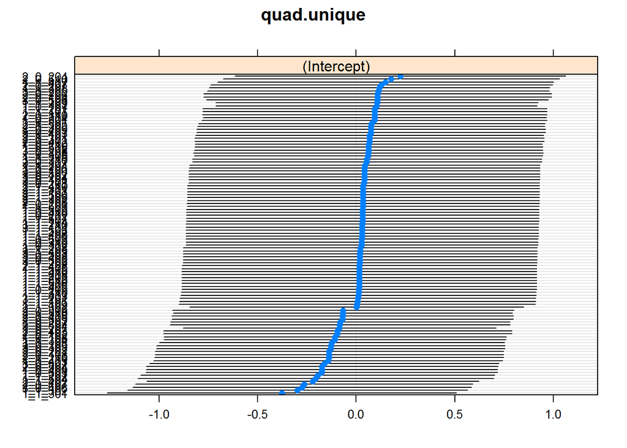

```
##
##
## $`Acer tegmentosum`
## $`Acer tegmentosum`$quad.unique
```

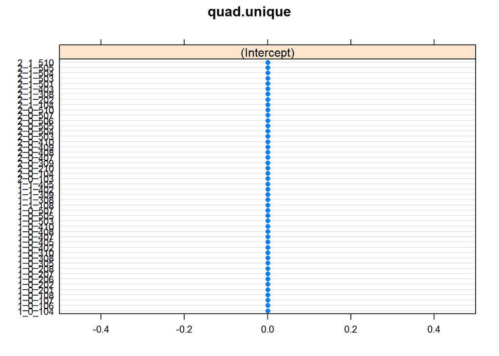

```
##
##
## $`Fraxinus mandschurica`
## $`Fraxinus mandschurica`$quad.unique
```

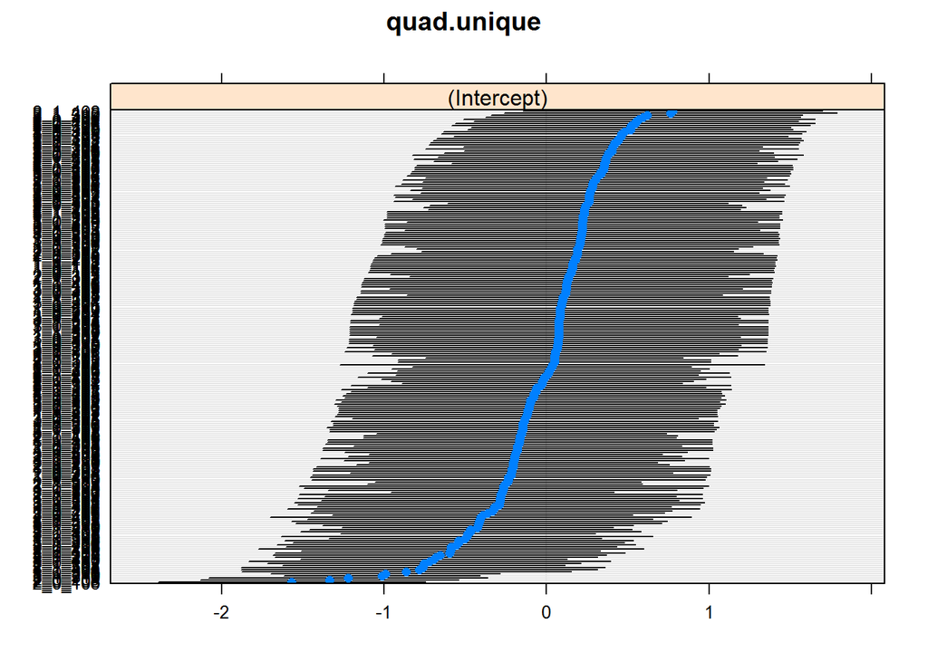

```
##
##
## $`Tilia amurensis`
## $`Tilia amurensis`$quad.unique
```

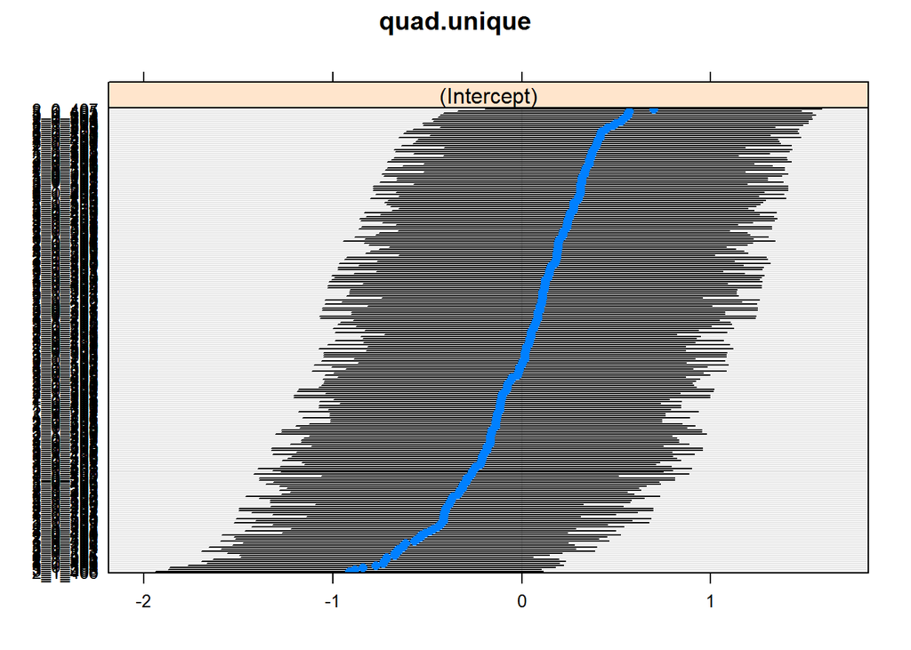

```r
lapply(nddmods, function(mod){
  dotplot(ranef(mod, condVar=TRUE))})
```

```r
## These still need some work., especially the T. amurensis model.
## which has a definite trend. Also, if you look at the A. tementosum model the random effects
## have 0 variance - so need to spend sometime on it.
lapply(nddmods, function(x) summary(x, correlation=FALSE))
```

```
## $`Acer barbinerve`
## Generalized linear mixed model fit by maximum likelihood (Laplace
##   Approximation) [glmerMod]
##  Family: binomial  ( logit )
## Formula: cbind(survs, deaths) ~ site + dens * (pesticide + exclosure) +
##     (1 | quad.unique)
##    Data: spdat
## Control:
## glmerControl(optimizer = "optimx", optCtrl = list(method = c("bobyqa",
##     "Nelder-Mead")))
##
##      AIC      BIC   logLik deviance df.resid
##      176      214      -75      150      124
##
## Scaled residuals:
##    Min     1Q Median     3Q    Max
## -5.134  0.175  0.387  0.471  1.187
##
## Random effects:
##  Groups      Name        Variance Std.Dev.
##  quad.unique (Intercept) 0.214    0.462
## Number of obs: 137, groups:  quad.unique, 108
##
## Fixed effects:
##                 Estimate Std. Error z value Pr(>|z|)
## (Intercept)      1.91010    0.63266    3.02   0.0025 **
## site2           -0.98636    0.51111   -1.93   0.0536 .
## site3           -0.30160    0.60232   -0.50   0.6166
## dens             4.73539    2.58617    1.83   0.0671 .
## pesticideW      -0.17996    0.67145   -0.27   0.7887
## pesticideF       0.40862    0.74013    0.55   0.5809
## pesticideI      -0.00502    0.69489   -0.01   0.9942
## exclosure1       0.56509    0.50175    1.13   0.2601
## dens:pesticideW -4.63975    2.58279   -1.80   0.0724 .
## dens:pesticideF -5.99230    2.79645   -2.14   0.0321 *
## dens:pesticideI -3.82809    2.65437   -1.44   0.1492
## dens:exclosure1 -1.39719    0.87278   -1.60   0.1094
## ---
## Signif. codes:  0 '***' 0.001 '**' 0.01 '*' 0.05 '.' 0.1 ' ' 1
##
```

[output cut: 103 more lines]

```
##                 Estimate Std. Error z value Pr(>|z|)
## (Intercept)       0.2880     0.2036    1.41  0.15715
## site2            -0.0739     0.1849   -0.40  0.68933
## site3             0.4247     0.1919    2.21  0.02689 *
## dens              0.8685     0.4483    1.94  0.05270 .
## pesticideW        0.0420     0.2233    0.19  0.85063
## pesticideF        0.9461     0.2447    3.87  0.00011 ***
## pesticideI        0.1961     0.2321    0.85  0.39799
## exclosure1        0.1483     0.1647    0.90  0.36787
## dens:pesticideW  -1.0437     0.4961   -2.10  0.03541 *
## dens:pesticideF  -1.0529     0.4957   -2.12  0.03368 *
## dens:pesticideI  -0.9711     0.5286   -1.84  0.06617 .
## dens:exclosure1  -0.1759     0.2957   -0.59  0.55187
## ---
## Signif. codes:  0 '***' 0.001 '**' 0.01 '*' 0.05 '.' 0.1 ' ' 1
```

```r
lapply(nddmods, function(x) anova(x))
```

```
## $`Acer barbinerve`
## Analysis of Variance Table
##                Df Sum Sq Mean Sq F value
## site            2   4.36   2.179    2.18
## dens            1   0.00   0.000    0.00
## pesticide       3   0.81   0.269    0.27
## exclosure       1   0.59   0.595    0.59
## dens:pesticide  3   4.97   1.657    1.66
## dens:exclosure  1   3.11   3.108    3.11
##
## $`Acer tegmentosum`
## Analysis of Variance Table
##                Df Sum Sq Mean Sq F value
## site            1  0.006   0.006    0.01
## dens            1  0.167   0.167    0.17
## pesticide       3  1.740   0.580    0.58
## exclosure       1  0.106   0.106    0.11
## dens:pesticide  3  2.521   0.840    0.84
## dens:exclosure  1  2.029   2.029    2.03
##
## $`Fraxinus mandschurica`
## Analysis of Variance Table
##                Df Sum Sq Mean Sq F value
## site            2   11.2     5.6    5.62
## dens            1   38.5    38.5   38.52
## pesticide       3    1.8     0.6    0.60
## exclosure       1    0.0     0.0    0.01
## dens:pesticide  3   12.7     4.2    4.24
## dens:exclosure  1    3.0     3.0    2.95
##
## $`Tilia amurensis`
## Analysis of Variance Table
##                Df Sum Sq Mean Sq F value
## site            2   7.62    3.81    3.81
## dens            1   0.17    0.17    0.17
## pesticide       3  22.85    7.62    7.62
## exclosure       1   0.67    0.67    0.67
## dens:pesticide  3   5.32    1.77    1.77
## dens:exclosure  1   0.36    0.36    0.36
```

What the individual models suggest overall is that 1. The effect of density is not negative - if anything, it is slightly positive - a finding that agrees with the result from the pooled data. 2. FUngicide and insecticide do not appear to change the slope of the relationship between density and survival in the expected direction. The one example where the interaction between density and pesticide appears significant and in the right direction is ’*Fraxinus mandschurica*. However, it is debatable how much that should be interpreted.

### 6. Analysis of diversity

First need to calculate the diversity in each quadrat.

```r
library(vegan)
```

```r
sp.diversity <- summarise(
  group_by(pestdat.ag, plot, quadrat, quad.unique, pesticide, exclosure, census),
  shannon=diversity(total), simpson=diversity(total, index='invsimpson'))
sp.diversity
```

```
## Source: local data frame [461 x 8]
## Groups: plot, quadrat, quad.unique, pesticide, exclosure [?]
##
##      plot quadrat quad.unique pesticide exclosure census shannon simpson
##    <fctr>   <int>      <fctr>    <fctr>    <fctr>  <chr>   <dbl>   <dbl>
## 1     1_0     101     1_0_101         W         0    16f    1.45    3.24
## 2     1_0     101     1_0_101         W         0    16s    1.33    3.60
## 3     1_0     102     1_0_102         C         0    16f    1.41    2.71
## 4     1_0     102     1_0_102         C         0    16s    1.56    4.50
## 5     1_0     103     1_0_103         I         0    16f    1.67    4.84
## 6     1_0     103     1_0_103         I         0    16s    1.49    4.00
## 7     1_0     104     1_0_104         C         0    16f    1.66    4.05
## 8     1_0     104     1_0_104         C         0    16s    1.37    3.86
## 9     1_0     105     1_0_105         F         0    16f    1.39    2.98
## 10    1_0     105     1_0_105         F         0    16s    1.49    4.00
## # ... with 451 more rows
```

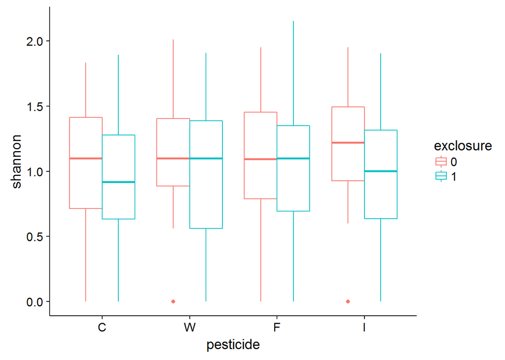

```r
ggplot(sp.diversity, aes(x=pesticide, y=shannon, colour = exclosure)) +
  geom_boxplot()
```

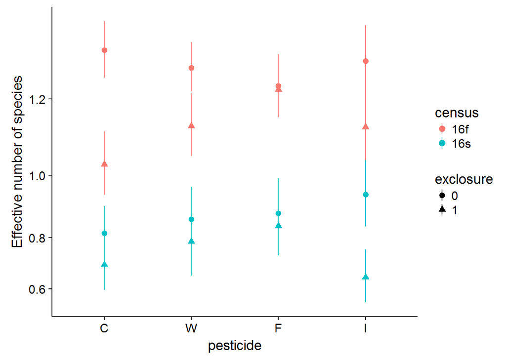

```r
summarise(group_by(sp.diversity, pesticide, exclosure, census), meanH=mean(shannon),
          seH=sd(shannon)/sqrt(length(shannon))) %>%
  ggplot(aes(x=pesticide, y=meanH, ymin=meanH-seH, ymax=meanH+seH, colour=census,
             shape=exclosure)) + geom_pointrange() + coord_trans(y="exp") +
  labs(x="pesticide", y="Effective number of species")
```

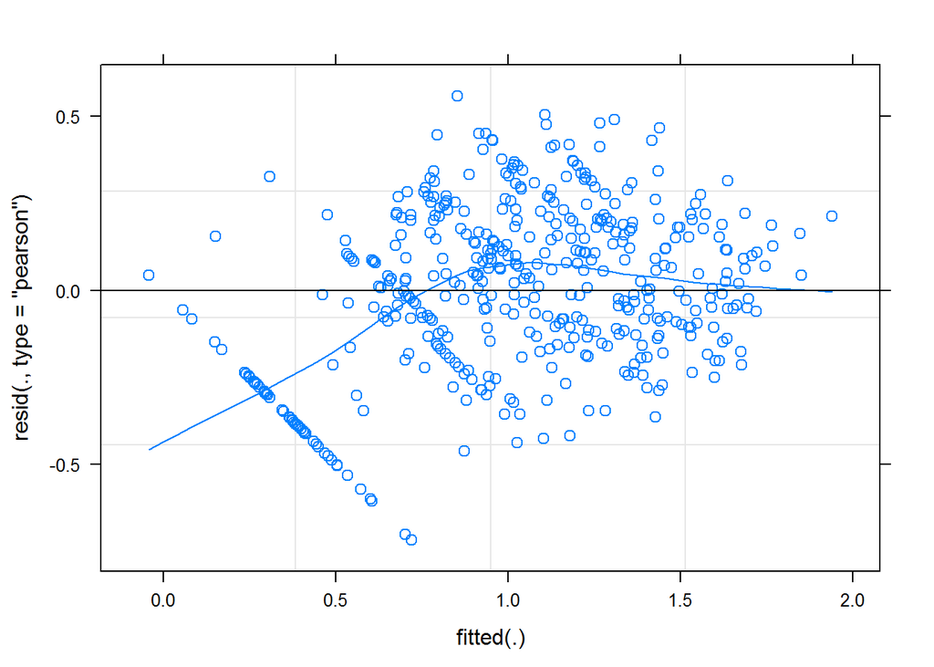

```r
sp.diversity$census <- factor(sp.diversity$census, levels=c('16s', '16f'))
mod.div <- lmer(shannon ~ census + pesticide*exclosure + (1|plot/quad.unique), data=sp.diversity)
plot(mod.div, type=c('p', 'smooth'))
```

```
## $`quad.unique:plot`
```

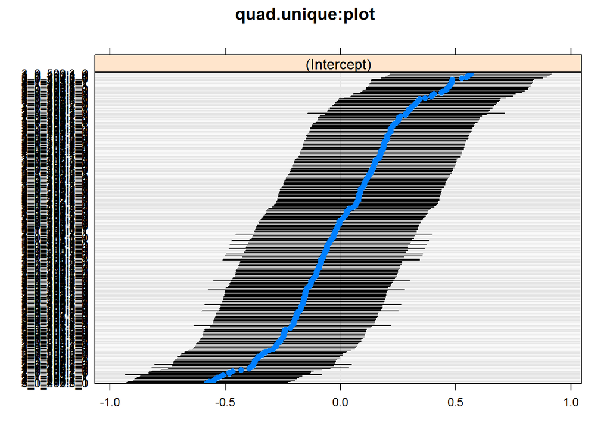

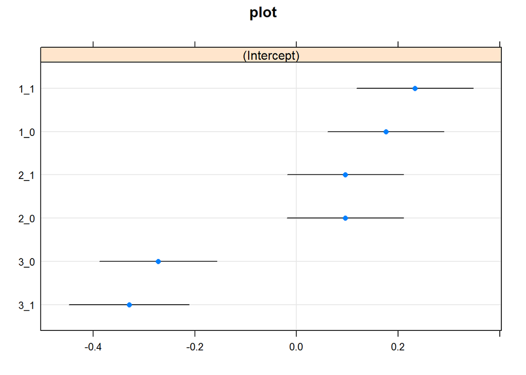

```r
## looks a little dodgy to me.
dotplot(ranef(mod.div, condVar=TRUE))
```

```
## Computing p-values via Kenward-Roger approximation. Use `p.kr = FALSE` if computation takes too long.
```

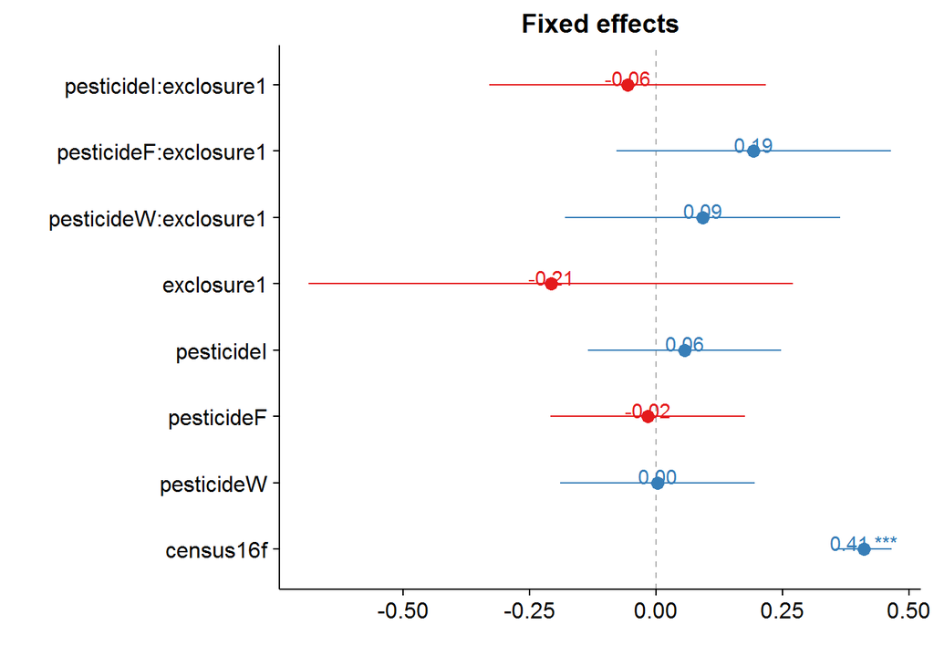

```r
library(sjPlot)
sjp.lmer(mod.div, type='fe')
```

```r
sjp.lmer(mod.div, type='re', sort.est="sort.all" )
```

```
## Sorting each group of random intercept ('sort.all') is not possible when 'facet.grid = TRUE'.
```

```
## Plotting random effects...
```

```
## Sorting each group of random intercept ('sort.all') is not possible when 'facet.grid = TRUE'.
```

```
## Plotting random effects...
```

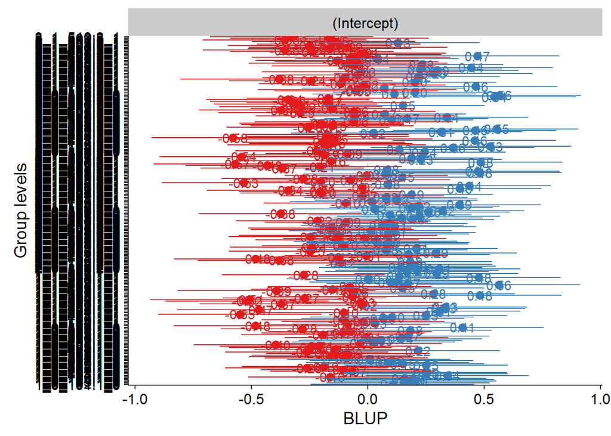

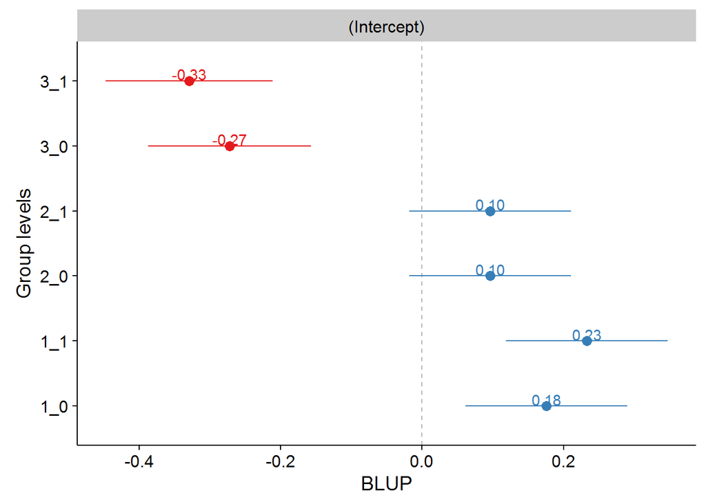

```
## $`quad.unique:plot`
```

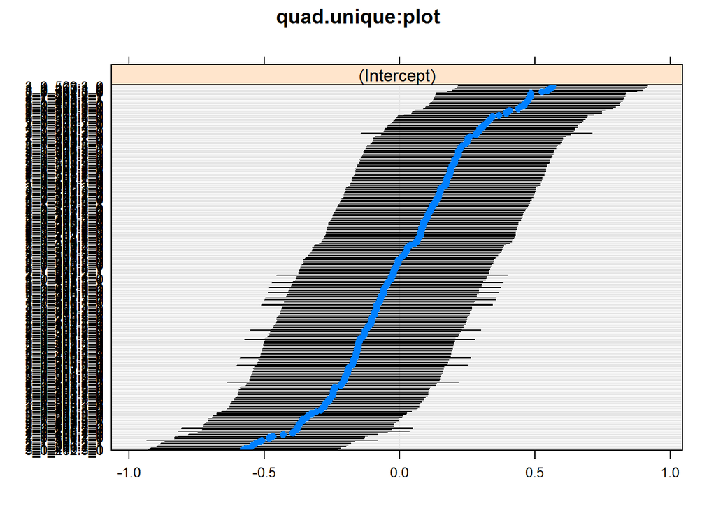

```r
dotplot(ranef(mod.div, condVar=TRUE, whichel="quad.unique:plot"))
```

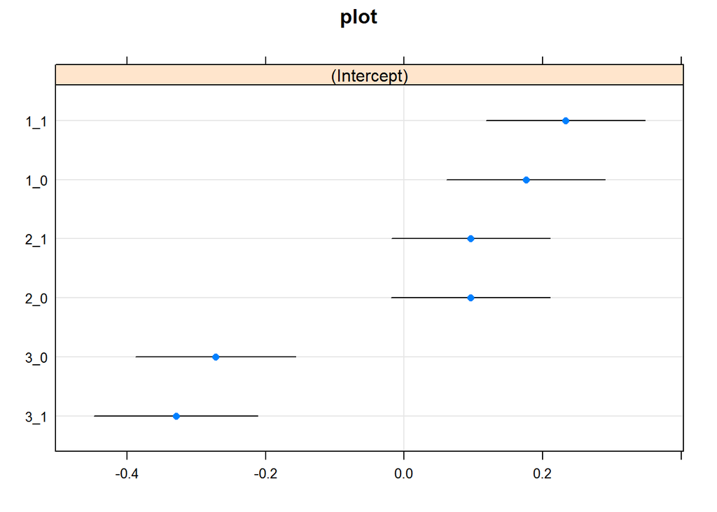

```r
dotplot(ranef(mod.div, condVar=TRUE, whichel="plot")) ## bit dodgy
```

```r
summary(mod.div, correlation=FALSE)
```

```
## Linear mixed model fit by REML ['lmerMod']
## Formula: shannon ~ census + pesticide * exclosure + (1 | plot/quad.unique)
##    Data: sp.diversity
##
## REML criterion at convergence: 498
##
## Scaled residuals:
##     Min      1Q  Median      3Q     Max
## -2.4178 -0.5548  0.0464  0.6071  1.8808
##
## Random effects:
##  Groups           Name        Variance Std.Dev.
##  quad.unique:plot (Intercept) 0.0976   0.312
##  plot             (Intercept) 0.0750   0.274
##  Residual                     0.0884   0.297
## Number of obs: 461, groups:  quad.unique:plot, 239; plot, 6
##
## Fixed effects:
##                       Estimate Std. Error t value
## (Intercept)            0.85263    0.17312    4.92
## census16f              0.41034    0.02799   14.66
## pesticideW             0.00289    0.09803    0.03
## pesticideF            -0.01692    0.09783   -0.17
## pesticideI             0.05637    0.09744    0.58
## exclosure1            -0.20832    0.24415   -0.85
## pesticideW:exclosure1  0.09145    0.13891    0.66
## pesticideF:exclosure1  0.19232    0.13849    1.39
## pesticideI:exclosure1 -0.05675    0.13929   -0.41
```

Overall, it doesn’t look like too much is happening here in terms of effects of treatment on diversity. Diversity increases over time, probably because we are seeing the establishment of the community from bare ground. There does seem to be a cosistent decrease in diversity in the exclosure treatment, but unfortunately, the lack of replication makes it hard to confirm.